# Análisis mtDNA: LSU

Simplemente para ver como sería el ajuste, pese a que este tipo de modelos creo que ya deberían quedar descartados.

```r
l_a <- c(0.0, 0.025,0.05)
for (a in l_a){
  # Eliminamos datos fuera de lugar
  lower_bound <- quantile(y, 0.00);lower_bound
  upper_bound <- quantile(y, 1 - a);upper_bound

  outlier_ind <- which(y < lower_bound | y > upper_bound)
  if (!is.na(outlier_ind[1])){
    data_tmp <- data_filtered[-outlier_ind,]
  }else{
    data_tmp <- data_filtered}
  dfs <- seq(15, 21, by = 3)
  #windows()
  par(mfrow=c(3,2))
  spls <- numeric(3)
  i <- 1
  for (df in dfs)
  {
    spls[i] <- splines_adjust(data_tmp, 'Log.GB.Seqs', 'CVTOT', df,6,0.5,1000,paste("P-Spline Regression ",df,'(K) alpha = ',a), type = 'p')
    i <- i + 1
  }
}
```

```
## [1] 3252.389
```

```
## [1] 3252.413
```

```
## [1] 3252.395
```

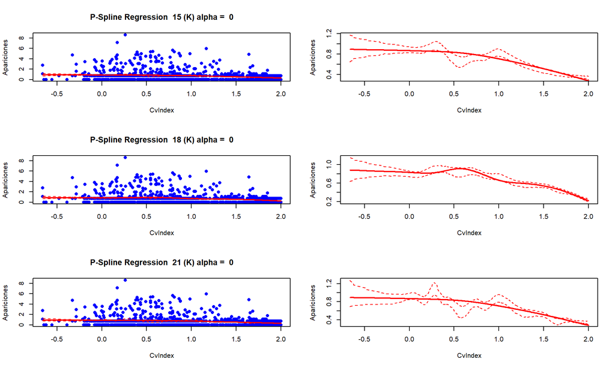

```
## [1] 2370.623
```

```
## [1] 2370.701
```

```
## [1] 2370.758
```

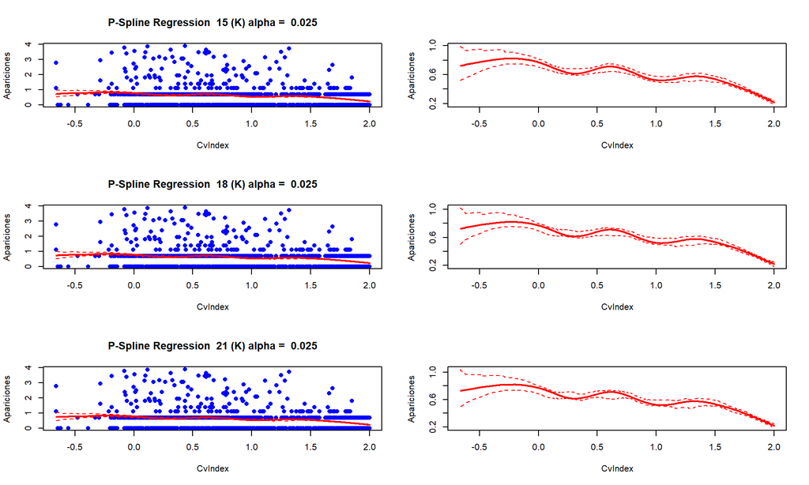

```
## [1] 1767.202
```

```
## [1] 1767.276
```

```
## [1] 1767.288
```

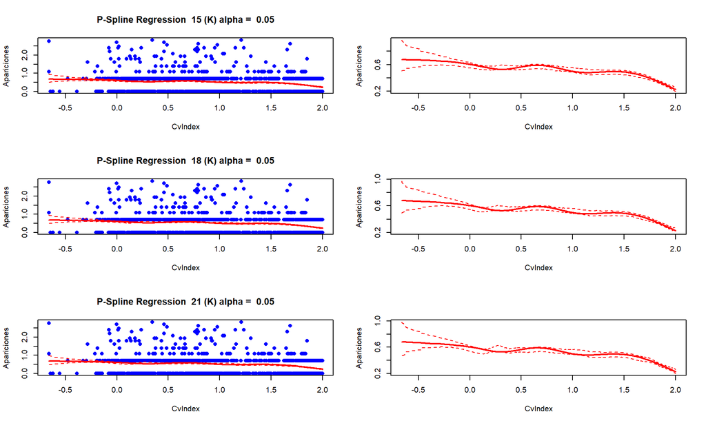

## Regresión logística: paramétrica y no paramétrica.

Tras lo comentado acerca de las diferencias entre el número de secuenciaciones asociadas a los distintos haplotipos es obvio que el número de apariciones en GenBank dependerá en gran medida del haplotipo que al que pertenezca la mutación. Por tanto, es probable que la magnitud de las ocurrencias en GenBank pueda no ser relevante y únicamente lo sea si aparece o no. En base a esta idea se plantea discretizar la variable GB.Seqs y ajustar tres modelos: regresión logística clásica, regresión logística local y loess.

- Opción A: poner a 1 si Apariciones > 0
- Opción B: poner a 1 si Apariciones > filtro, con filtro > 1, a la vista de los resultados del histograma no parece sensato dado que eliminaríamos la mayor parte de la información y nos quedaríamos con muy pocos datos para hacer la regresión.

```r
par(c(1,3))
```

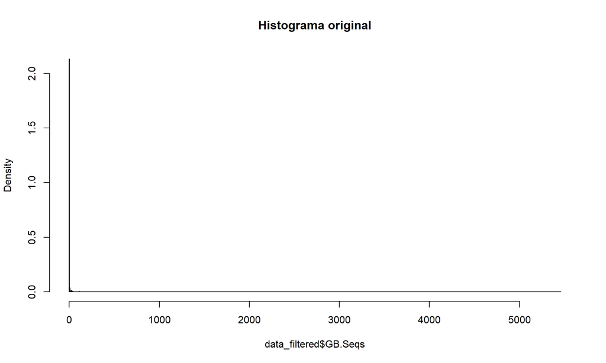

```r
hist(data_filtered$GB.Seqs, breaks = 'fd', freq = F, main = 'Histograma original')
```

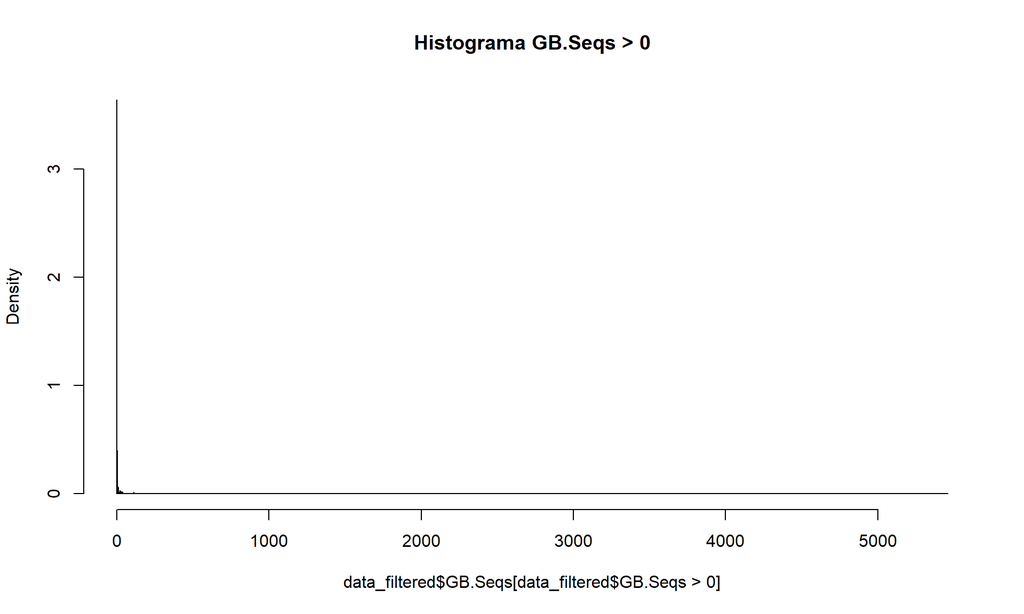

```r
hist(data_filtered$GB.Seqs[data_filtered$GB.Seqs > 0], breaks = 'fd', freq = F, main = 'Histograma GB.Seqs > 0')
```

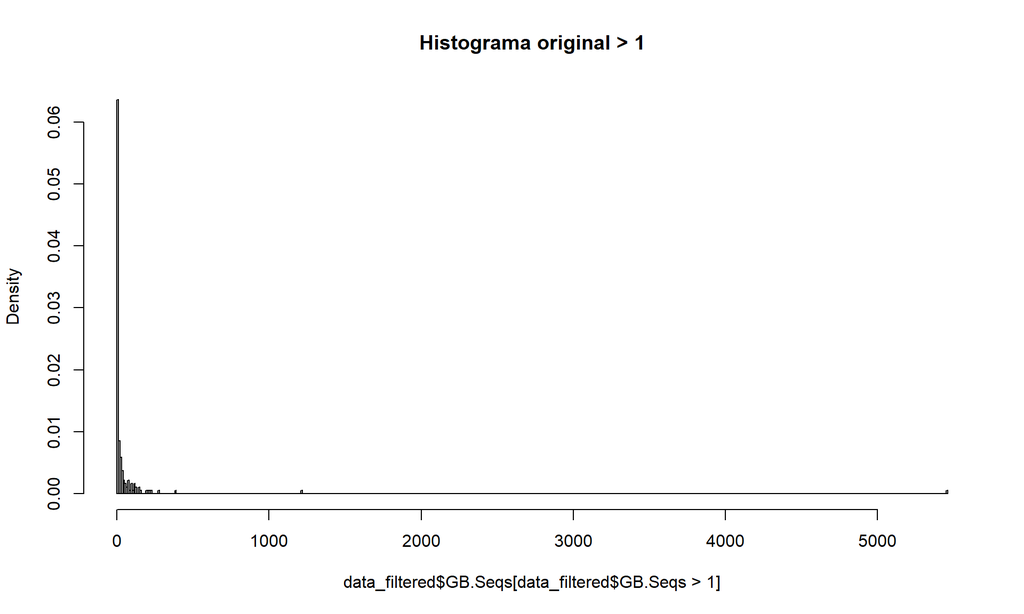

```r
hist(data_filtered$GB.Seqs[data_filtered$GB.Seqs > 1], breaks = 'fd', freq = F, main = 'Histograma original > 1')
```

```r
data_filtered$Bin.GB.Seqs[data_filtered$GB.Seqs > 0] <- 1
# Regresiones logísticas
plot(data_filtered$CVTOT,data_filtered$Bin.GB.Seqs,pch=16,col="blue",ylim=c(0,1),xlab="CvIndex",ylab="Bin(Appearances)")
# Regresión logística clásica
mod_logit <- glm(Bin.GB.Seqs~CVTOT, family = binomial(link = 'logit'), data = data_filtered)
print(AIC(mod_logit))
```

```
## [1] 1562.503
```

```r
# Predictions
x_pred <- data.frame(CVTOT = seq(-1,2, length = 1000))
pred <- predict(mod_logit, x_pred,se.fit = T, type = 'response')
lines(x_pred$CVTOT, pred$fit, col = 'red', lwd = 2)
lines(x_pred$CVTOT, pred$fit + pred$se.fit*1.96, col = 'red', lty = 2)
lines(x_pred$CVTOT, pred$fit - pred$se.fit*1.96, col = 'red', lty = 2)

# Regresión loess (olvidamos el carácter dicotómico de la variable)
idx <- sort(data_filtered$CVTOT,index.return=TRUE)$ix
x_sort <- data_filtered$CVTOT[idx]
y_sort=data_filtered$Bin.GB.Seqs[idx]
lo <- gamlss(y_sort~lo(~x_sort), family = 'BI')
```

```
## GAMLSS-RS iteration 1: Global Deviance = 1549.77
## GAMLSS-RS iteration 2: Global Deviance = 1549.8
## GAMLSS-RS iteration 3: Global Deviance = 1549.8
```

```r
pred_lo <- predict(lo, se = TRUE)
lines(x_sort,pred_lo$fit,col="green",lwd=2)
lines(x_sort,pred_lo$fit+pred_lo$se.fit*1.96,col="green",lwd=1, lty = 2)
lines(x_sort,pred_lo$fit-pred_lo$se.fit*1.96,col="green",lwd=1, lty = 2)
print(AIC(lo))
```

```
## [1] 1559.515
```

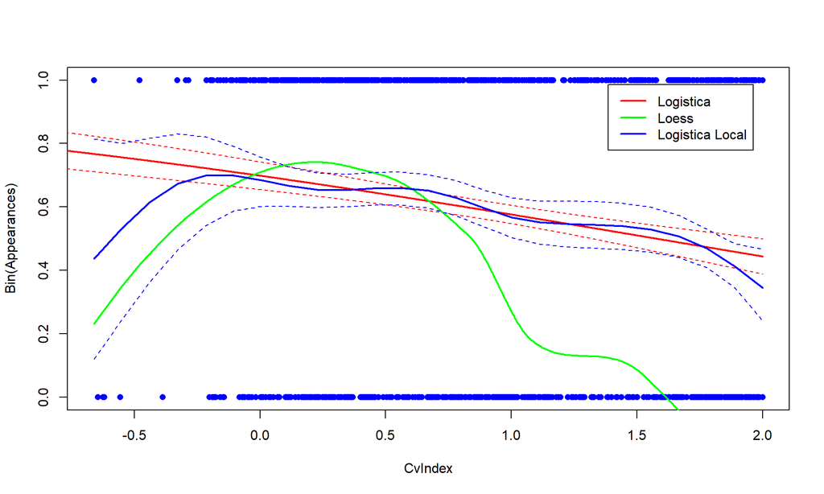

```r
# Regresión logística local
h <- h.select(data_filtered$CVTOT, data_filtered$Bin.GB.Seqs)
log_loc <- sm.binomial(data_filtered$CVTOT,data_filtered$Bin.GB.Seqs,h=h,add=T,col="red",lwd=2,pch=28,ylim=c(0,0.3))
lines(log_loc$eval.points,log_loc$estimate,type="l",col="blue",lwd=2)
lines(log_loc$eval.points,log_loc$upper,col="blue",lty=2)
lines(log_loc$eval.points,log_loc$lower,col="blue",lty=2)

legend("topright", c("Logistica","Loess","Logistica Local"),lty=c(1,1,1),col=c('red', 'green','blue'),ncol=1,lwd=rep(2,3), inset = .05)
```

A la vista de los resultados parece lógico decir que la regresión logística clásica obvia la caída final de probabilidad, pero por otro lado parece correlar en gran medida con los visto para los ajustes no paramétricos tipo, spline.